THE STORY

Every season, there are a no. of players, which go under the radar i.e. they perform well, but either they are in lower ranked team, or their teammates are performing way better than they are, so they sort of become anonymous.

Now, the ultimate metric to identify whether a player is a top one or not is the market value of the player. The higher the market, the better the player is expected to be. Teams need to buy top players, but looking at market value isn’t always the best way to decide which players to buy, especially considering the teams with low budget.

For this project, we have assumed that we’ve been hired as analysts by a team with aspirations, but with a low budget. Our task here would be to find 3 players, a defender, a midfielder and an attacker with the best value for money i.e. we need to find gems who will elevate our team and possibly earn the team much needed revenue by selling them for a higher value next season.

First of all, we are going to need the libraries that we are going to need for our project.

```r
library(tidyverse)
library(ggplot2)
library(Hmisc)
library(scales)
library(ggalt)
library(kableExtra)
```

Now we will read our data into a dataframe named logs.

```r
setwd("d:/usama/Content/Sports Data/project 2/All")
logs <- read_csv("Stats2.csv ")
```

```r
defenders <- logs %>%
  filter(Position == "DF", MinutesPlayed >=700) %>%
  arrange(desc(MarketValue))

midfielders <- logs %>%
  filter(Position == "MF", MinutesPlayed >=600) %>%
  arrange(desc(MarketValue))

forwards <- logs %>%
  filter(Position == "FW", MinutesPlayed >=600) %>%
  arrange(desc(MarketValue))
```

We’ve sorted the players by their market value. The dataframes show that the top players have the highest market values.

First, we need to find how are we going to find the cheapest players. We can look at the leagues, and see if players in certain leagues are cheaper than others. So, we are going to create a new dataframe in which average values of leagues will be compared with each other.

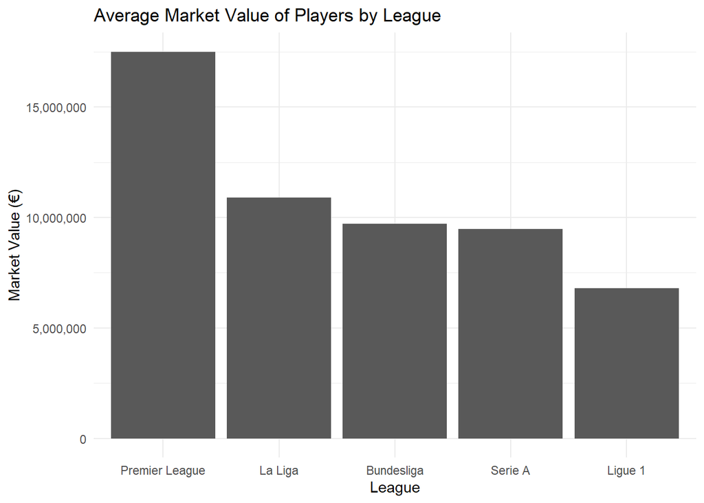

```r
leagueValues = logs %>%
  group_by(League) %>%
  summarise(MarketValue = mean(MarketValue))

ggplot(leagueValues, aes(x = reorder(League, -MarketValue), weight = MarketValue)) +
  geom_bar() +
  scale_y_continuous(labels = comma) +
  labs(title = "Average Market Value of Players by League",
       x = "League",
       y = "Market Value (€)") +
  theme_minimal()
```

We can see from the above graph that player values vary by leagues. We are going to find the cheapest defenders in Ligue 1, so that will be our preference, but we might find some gems in other leagues as well.

What else can we look at? What about age, does age impact the market values of the players. Lets see.

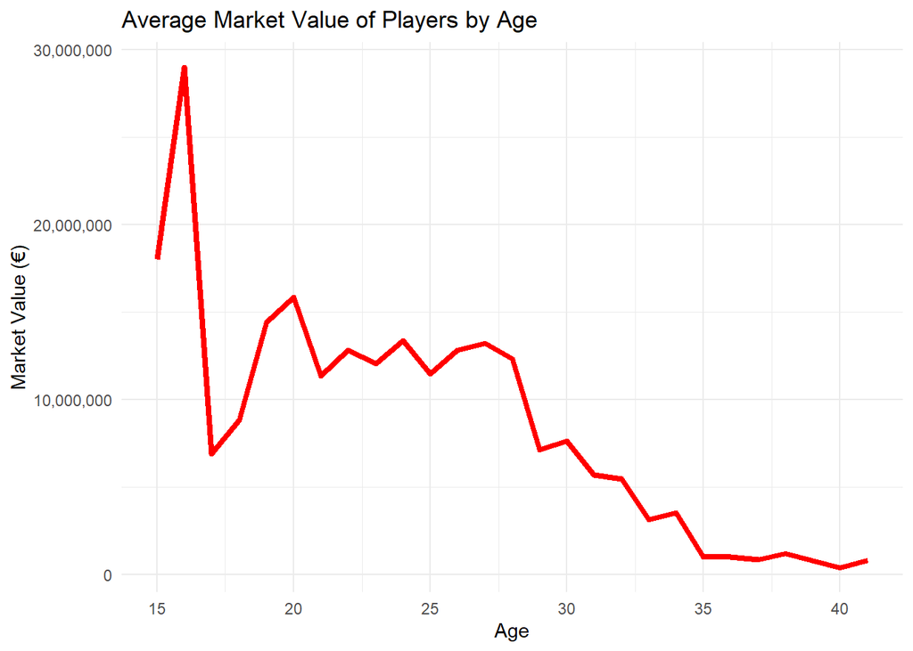

```r
ageValues = logs %>%
  group_by(Age) %>%
  summarise(MarketValue = mean(MarketValue))

ggplot() +
  geom_line(data=ageValues, aes(x = Age, y = MarketValue), color = "red", size = 1.5) +
  scale_y_continuous(labels = comma) +
  labs(title = "Average Market Value of Players by Age",
       x = "Age",
       y = "Market Value (€)") +
  theme_minimal()
```

We can see a trend here. As the age increase, the market values drop. Thats expected, because the players performance also decline with age. Ideally, we should be looking at player profiles with age from 28 to 30 to get the best value for money. But thats trade-off. If we want to sell that player next year, we won’t be getting a lot of money. So we’ll need to look at a player younger than that.

Now we’re going to look at some of the features that we require in our defender. We will create a new column, the DefenseScore, which will be the sum of the things we need in our defender. In addition to that, we have our preferences, that the Age must be less than 28 (explained above) and the market price should be less than 5m (Budget constraints).

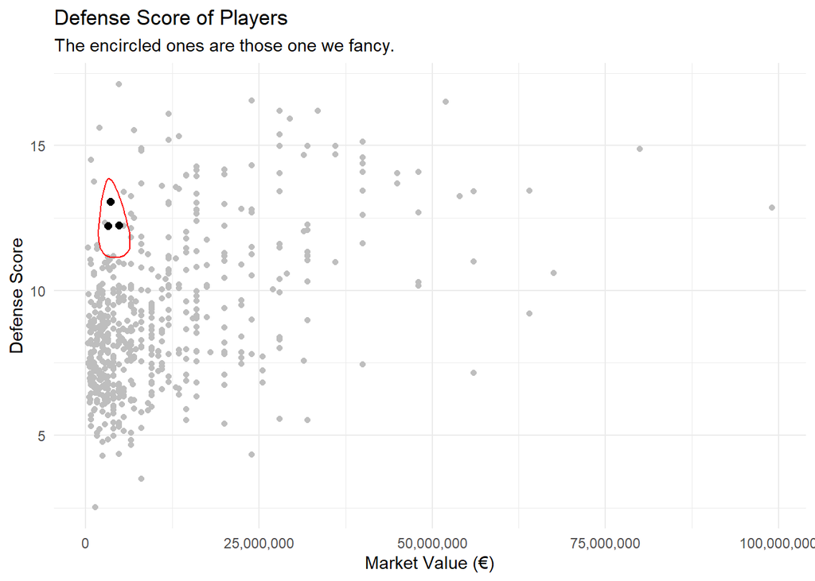

```r
dfScr <- defenders %>%
  group_by(Players, Position, Squad, League, Age, `90s`) %>%
  select(`TacklesWon/90`,
         `Interceptions/90`,
         `PassesCompleted/90`,
         `DribblePast/90`,
         `ShotBlocks/90`,
          MarketValue) %>%
  mutate(DefenseScore = (.2*as.numeric(`TacklesWon/90`)) +
           (.2*as.numeric(`Interceptions/90`)) +
           (.2*as.numeric(`PassesCompleted/90`) -
           (.2*as.numeric(`DribblePast/90`) -
           (.2*as.numeric(`ShotBlocks/90`)) ))) %>%
  arrange(desc(DefenseScore))

dfScrFilter <- dfScr %>%
  filter (DefenseScore >= 12 & Age <= 28 & MarketValue < 5000000)

ggplot() +
  geom_point(data = dfScr,
             aes(x = MarketValue, y = DefenseScore),
             color = "grey", size = 1.5) +
  geom_point(data = dfScrFilter,
             aes(x = MarketValue,y = DefenseScore),
             color = "Black",
             size = 2) +
  geom_encircle(data = dfScrFilter,
                aes(x = MarketValue, y = DefenseScore),
                s_shape = 0.05,
                expand = 0.05,
                colour = "red") +
  scale_x_continuous(labels = comma) +
  labs(title = "Defense Score of Players",
       subtitle = "The encircled ones are those one we fancy." ,
       x = "Market Value (€)",
       y = "Defense Score") +
  theme_minimal()
```

We have plotted the graph above, which shows that there are players above which provide good value for money, in fact, there are three of them. No surprises there, as two of them are from Ligue 1, as deduced earlier.

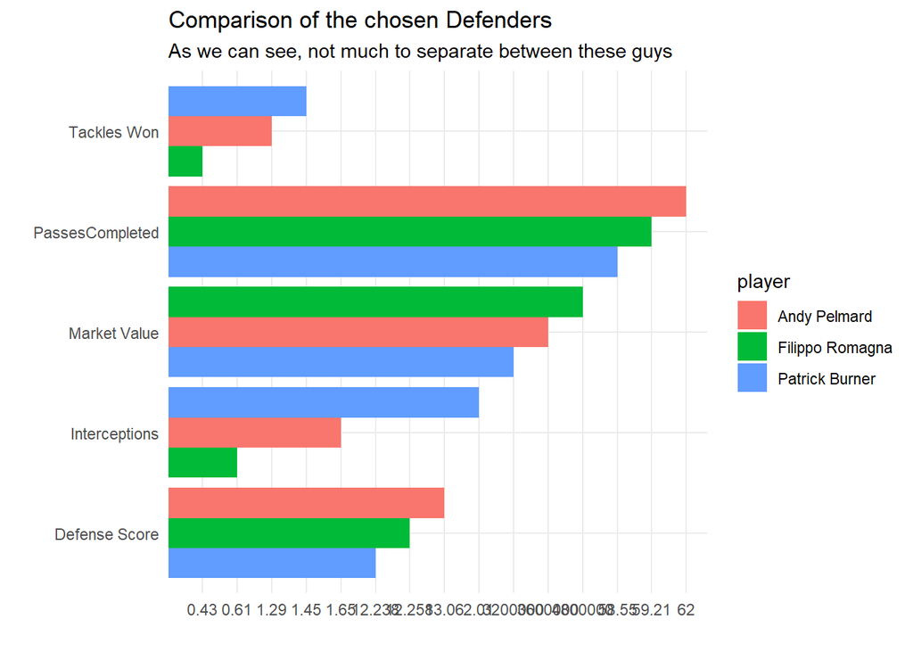

```r
stats <- c(rep("Tackles Won" , 3) ,
           rep("Interceptions" , 3) ,
           rep("PassesCompleted" , 3) ,
           rep("Defense Score" , 3),
           rep("Market Value", 3))

player <- rep(c("Andy Pelmard" , "Filippo Romagna" , "Patrick Burner") , 5)

value <- c(dfScrFilter$`TacklesWon/90`,
           dfScrFilter$`Interceptions/90`,
           dfScrFilter$`PassesCompleted/90`,
           dfScrFilter$DefenseScore,
           dfScrFilter$MarketValue)

data <- data.frame(stats, player, value)

ggplot(data, aes(fill = player, y = value, x = stats)) +
  geom_bar(position = "dodge", stat = "identity") +
  labs(title = "Comparison of the chosen Defenders",
       subtitle = "As we can see, not much to separate between these guys",
       x = "", y = "") +
  coord_flip() +
  theme_minimal()
```

Comparing the required stats of the three, we can see that there is not much difference between these players, so we can choose anyone. Our pick here would be Filippo Romagna, although he is a bit expensive, he is playing in Serie A, which is higher rated than Ligue 1. He’s 22 years old, and has loads of time to improve further.

```r
pickDef <- logs %>%
  filter(Players == "Filippo Romagna")
```

Before spending our 4.8m, we need to be sure how he compares with the rest of defenders in the stats that we care about.

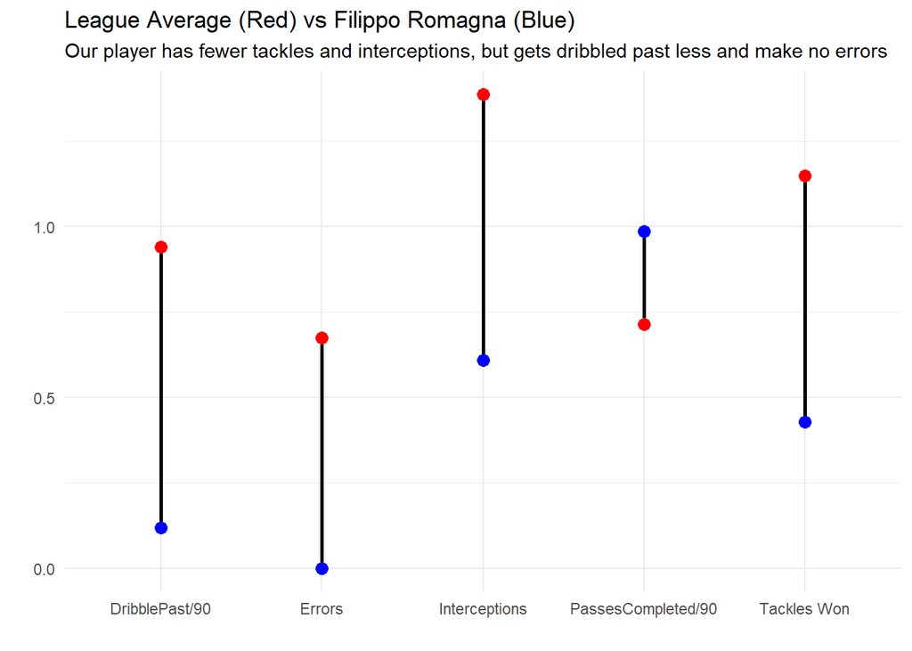

```r
compDef <- defenders %>%
  group_by(Position) %>%
  summarise(`TacklesWon/90` = mean(as.numeric(`TacklesWon/90`)),
            `Interceptions/90` = mean(as.numeric(`Interceptions/90`)),
             Errors = mean(as.numeric(Errors)),
            `DribblePast/90` = mean(as.numeric(`DribblePast/90`)),
            `PassesCompleted/90` = mean(as.numeric(`PassesCompleted/90`))/60)

pickDef <- pickDef %>%
  group_by(Position) %>%
  summarise(`TacklesWon/90` = mean(as.numeric(`TacklesWon/90`)),
            `Interceptions/90` = mean(as.numeric(`Interceptions/90`)),
             Errors = mean(as.numeric(Errors)),
            `DribblePast/90` = mean(as.numeric(`DribblePast/90`)),
            `PassesCompleted/90` = mean(as.numeric(`PassesCompleted/90`))/60)

compDef <- rbind(compDef, pickDef)

stats <- c(rep("Tackles Won" , 2) ,
           rep("Interceptions" , 2) ,
           rep("Errors" , 2) , rep("DribblePast/90" , 2),
           rep("PassesCompleted/90",2) )

player <- rep(c("All Defendors" , "Filippo Romagna") , 5)

value <- c(compDef$`TacklesWon/90`,
           compDef$`Interceptions/90`,
           compDef$Errors,
           compDef$`DribblePast/90`,
           compDef$`PassesCompleted/90`)

data <- data.frame(player, stats, value)

pl <- data %>% group_by(stats) %>% filter(player == "All Defendors") %>% select(Stats = stats, 'All Defenders' = value)
fr <- data %>% group_by(stats) %>% filter(player == "Filippo Romagna") %>% select(Stats = stats, 'Filippo Romagna' = value)

all <- left_join(pl,fr)

ggplot(all) +
  geom_segment(aes(x = Stats, xend = Stats, y = `All Defenders`, yend = `Filippo Romagna`), color = "black", size = 1) +
  geom_point(aes(x = Stats, y = `All Defenders`), color = "red", size = 3) +
  geom_point(aes(x = Stats, y = `Filippo Romagna`), color = "blue", size = 3) +
  labs(title = "League Average (Red) vs Filippo Romagna (Blue)",
       subtitle = "Our player has fewer tackles and interceptions, but gets dribbled past less and make no errors",
       x = "", y = "") +
  theme_minimal()
```

The stats show how our selected player compares with the rest of league averages. Although he has fewer tackles and interceptions per 90, he makes less errors, and gets dribbled past rarely. Also his completed passes in 90 are ahead of league average, so its a safe bet to get this player as a defender.

Moving on, we need to find a midfielder who satisfies our criteria. For midfield, we will search for players who have high amount of passes in the final third of the field, high no. of assists and expected assists. The midfielder should be able to pass the ball under pressure, and should be able to provide a decent throughball. So lets create a data frame with the sum of required stats MidfieldScore mutated into our dataframe, and filter the players according to our criteria. For midfield, the market value should be less than 10m.

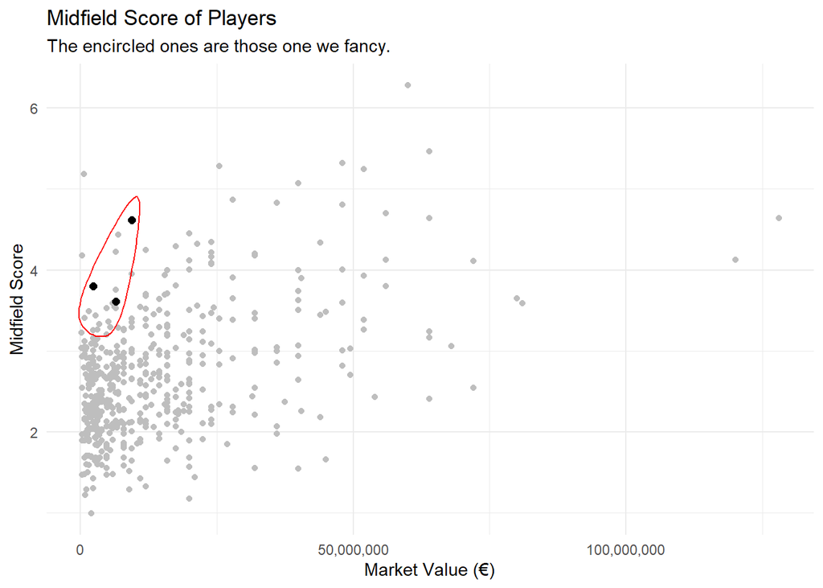

```r
mfScr <- midfielders %>%
  group_by(Players, Position, Squad, League, Age, `90s`) %>%
  select(`PassesFinalThird/90`,
         `Assists/90`,
         `xA/90`,
         `PassesPress/90`,
         `ThroughBalls/90`,
          MarketValue) %>%
  mutate(MidfieldScore = (.2*as.numeric(`PassesFinalThird/90`)) +
           (.2*as.numeric(`Assists/90`)) +
           (.2*as.numeric(`xA/90`)) +
           (.2*as.numeric(`PassesPress/90`)) +
           (.2*as.numeric(`ThroughBalls/90`)) ) %>%
  arrange(desc(MidfieldScore))

mfScrFilter <- mfScr %>%
  filter (MidfieldScore >=3.6 & Age <= 28 & MarketValue < 10000000)

ggplot() +
  geom_point(data = mfScr, aes(x = MarketValue, y = MidfieldScore), color = "grey", size = 1.5) +
  geom_point(data = mfScrFilter, aes(x = MarketValue, y = MidfieldScore), color = "Black", size = 2) +
  geom_encircle(data = mfScrFilter,
                aes(x = MarketValue, y = MidfieldScore),
                s_shape = 0.05,
                expand = 0.05,
                colour = "red") +
  scale_x_continuous(labels = comma) +
  labs(title = "Midfield Score of Players",
       subtitle = "The encircled ones are those one we fancy." ,
       x = "Market Value (€)",
       y = "Midfield Score") +
  theme_minimal()
```

And we have found 3 players who fulfill our criteria. Let’s compare them with each other and see who comes out on top.

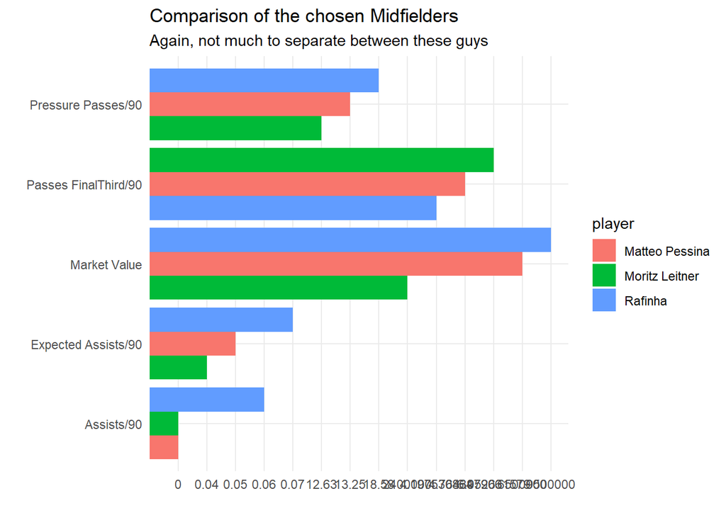

```r
stats <- c(rep("Passes FinalThird/90" , 3) ,
           rep("Assists/90" , 3) ,
           rep("Expected Assists/90" , 3) ,
           rep("Pressure Passes/90" , 3),
           rep("Market Value", 3))

player <- rep(c("Rafinha" , "Moritz Leitner" , "Matteo Pessina") , 5)

value <- c(mfScrFilter$`PassesFinalThird/90`,
           mfScrFilter$`Assists/90`,
           mfScrFilter$`xA/90`,
           mfScrFilter$`PassesPress/90`,
           mfScrFilter$MarketValue)

data <- data.frame(stats, player, value)

ggplot(data, aes(fill=player, y=value, x=stats)) +
  geom_bar(position="dodge", stat="identity") +
  labs(title="Comparison of the chosen Midfielders",
       subtitle = "Again, not much to separate between these guys",
       x = "", y = "") +
  coord_flip() +
  theme_minimal()
```

The three players closely contest each other. We will go for the player with minimum value here, which is Moritz Leitner.

```r
pickMid <- logs %>%
  filter(Players == "Moritz Leitner")
```

Lets compare Mortitz Leitner’s stats with the rest of players of the top 5 leagues.

[figure not shown]

```r
compMid <- midfielders %>%
  group_by(Position) %>%
  summarise(`PassesFinalThird/90` = mean(as.numeric(`PassesFinalThird/90`))/5,
            `Pass%` = mean(as.numeric(`Pass%`))/100,
            `xA/90` = mean(as.numeric(`xA/90`)),
            `PassesPress/90` = mean(as.numeric(`PassesPress/90`))/10,
            `ThroughBalls/90` = mean(as.numeric(`ThroughBalls/90`)))

pickMid <- pickMid %>%
  group_by(Position) %>%
  summarise(`PassesFinalThird/90` = mean(as.numeric(`PassesFinalThird/90`))/5,
            `Pass%` = mean(as.numeric(`Pass%`))/100,
            `xA/90` = mean(as.numeric(`xA/90`)),
            `PassesPress/90` = mean(as.numeric(`PassesPress/90`))/10,
            `ThroughBalls/90` = mean(as.numeric(`ThroughBalls/90`)))

compMid <- rbind(compMid, pickMid)

stats <- c(rep("Passes to Final Third/90" , 2) ,
           rep("Pass Percentage" , 2) ,
           rep("Expected Assists/90" , 2) ,
           rep("Pressure Passes /90" , 2),
           rep("Through Balls/90", 2))

player <- rep(c("All Midfielders" , "Moritz Leitner") , 5)

value <- c(compMid$`PassesFinalThird/90`,
           compMid$`Pass%`,
           compMid$`xA/90`,
           compMid$`PassesPress/90`,
           compMid$`ThroughBalls/90`)

data <- data.frame(player, stats, value)

pl <- data %>% group_by(stats) %>% filter(player == "All Midfielders") %>% select(Stats = stats, 'All Midfielders' = value)
fr <- data %>% group_by(stats) %>% filter(player == "Moritz Leitner") %>% select(Stats = stats, 'Moritz Leitner' = value)

all <- left_join(pl,fr)

ggplot(all) +
  geom_segment(aes(x=Stats, xend=Stats, y=`All Midfielders`, yend=`Moritz Leitner`), color="black", size = 1) +
  geom_point(aes(x=Stats, y=`All Midfielders`), color="red", size = 3) +
  geom_point(aes(x=Stats, y=`Moritz Leitner`), color="blue", size = 3) +
  labs(title="League Average (Red) vs Moritz Leitner (Blue)",
       subtitle = "Our chosen player is better in all of the concerned stats.",
       x = "", y = "") +
  theme_minimal() +
  coord_flip()
```

Looks like we’ve got a gem here. Moritz Leitner’s age profile is very solid, and combined with low market value, he is the best choice pound for pound in our team.

With the midfield and defense done, lets move to forwards. We need to find forwards with a tendency to show high amount of expected goals, and his goal creation contribution should be respectable. Also, he should know how to dribble, and is disposessed rarely. These are the parameters that will comprise our ForwardScore. Lets see who comes out on top in our criteria.

[figure not shown]

```r
fwScr <- forwards %>%
  group_by(Players, Position, Squad, League, Age, `90s`) %>%
  select(`xG/90`,
         `SoT/90`,
         `GoalCreationActions/90`,
         `DribblesSuccessful/90`,
         `Disposessed/90`,
          MarketValue) %>%
  mutate(ForwardScore = (.2*as.numeric(`xG/90`)) +
           (.2*as.numeric(`SoT/90`)) +
           (.2*as.numeric(`GoalCreationActions/90`)) +
           (.2*as.numeric(`DribblesSuccessful/90`)) -
           (.2*as.numeric(`Disposessed/90`)) ) %>%
  arrange(desc(ForwardScore))


fwScrFilter <- fwScr %>%
  filter (ForwardScore >=0.5 & Age <= 28 & MarketValue < 10000000)

ggplot() +
  geom_point(data = fwScr, aes(x=MarketValue, y=ForwardScore), color = "grey", size = 1.5) +
  geom_point(data = fwScrFilter, aes(x=MarketValue,y=ForwardScore), color="Black",size=2) +
  geom_encircle(data = fwScrFilter,
                aes(x=MarketValue, y=ForwardScore),
                s_shape=0.05,
                expand=0.05,
                colour="red") +
  scale_x_continuous(labels = comma) +
  labs(title="Midfield Score of Players",
       subtitle = "The encircled ones are those one we fancy." ,
       x = "Market Value (€)",
       y = "Midfield Score") +
  theme_minimal()
```

This time, we got four players. Lets choose 1 from them by comparison.

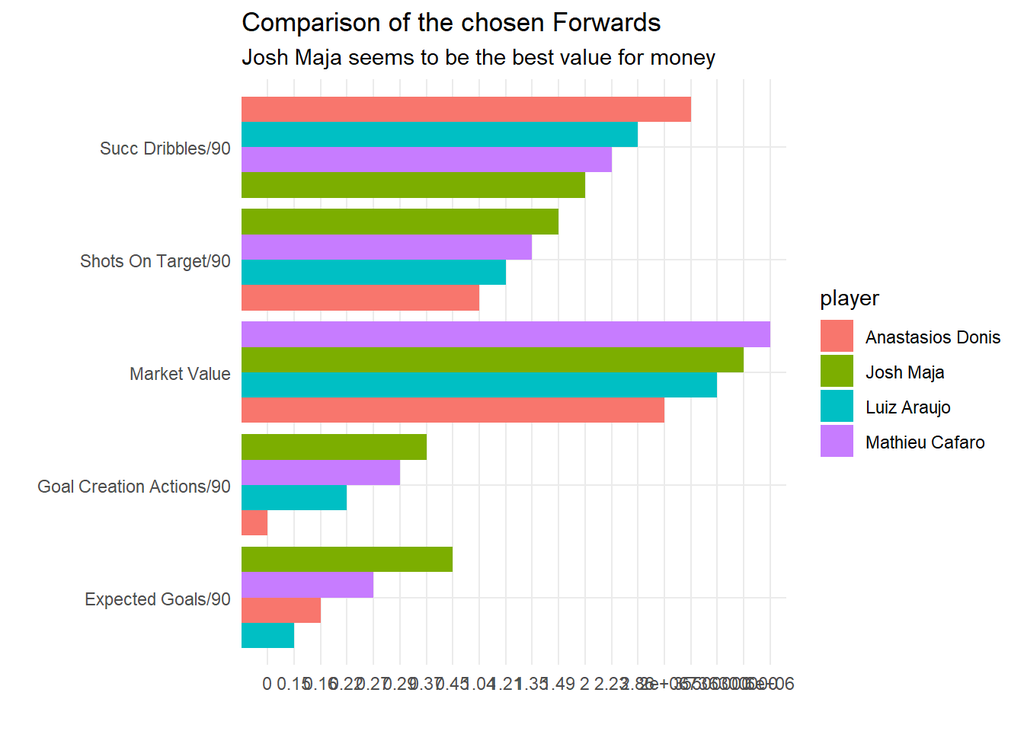

```r
stats <- c(rep("Expected Goals/90" , 4) ,
           rep("Shots On Target/90" , 4) ,
           rep("Goal Creation Actions/90" , 4) ,
           rep("Succ Dribbles/90" , 4),
           rep("Market Value", 4))

player <- rep(c("Anastasios Donis" , "Mathieu Cafaro" , "Luiz Araujo", "Josh Maja") , 5)

value <- c(fwScrFilter$`xG/90`,
           fwScrFilter$`SoT/90`,
           fwScrFilter$`GoalCreationActions/90`,
           fwScrFilter$`DribblesSuccessful/90`,
           fwScrFilter$MarketValue)

data <- data.frame(stats, player, value)

ggplot(data, aes(fill = player, y = value, x = stats)) +
  geom_bar(position = "dodge", stat = "identity") +
  labs(title = "Comparison of the chosen Forwards",
       subtitle = "Josh Maja seems to be the best value for money",
       x = "", y = "") +
  coord_flip() +
  theme_minimal()
```

And we have rather standout player; Josh Maja. This will be our pick in the forwards.

```r
pickFw <- logs %>%
  filter(Players == "Josh Maja")
```

As with the midfield and defense, we’ve got to compare how our chosen player fares with the rest of the forwards.

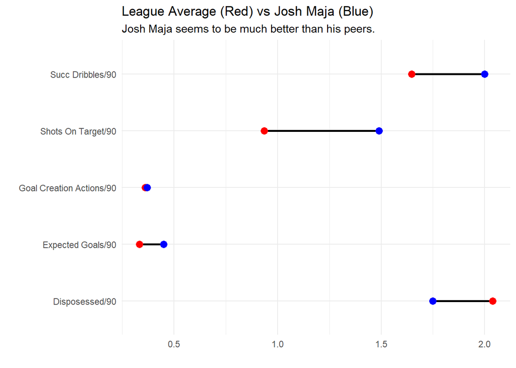

```r
compFw <- forwards %>%
  group_by(Position) %>%
  summarise(`xG/90` = mean(as.numeric(`xG/90`)),
            `SoT/90` = mean(as.numeric(`SoT/90`)),
            `GoalCreationActions/90` = mean(as.numeric(`GoalCreationActions/90`)),
            `DribblesSuccessful/90` = mean(as.numeric(`DribblesSuccessful/90`)),
            `Disposessed/90` = mean(as.numeric(`Disposessed/90`)))

pickFw <- pickFw %>%
  group_by(Position) %>%
  summarise(`xG/90` = mean(as.numeric(`xG/90`)),
            `SoT/90` = mean(as.numeric(`SoT/90`)),
            `GoalCreationActions/90` = mean(as.numeric(`GoalCreationActions/90`)),
            `DribblesSuccessful/90` = mean(as.numeric(`DribblesSuccessful/90`)),
            `Disposessed/90` = mean(as.numeric(`Disposessed/90`)))

compFw <- rbind(compFw, pickFw)

stats <- c(rep("Expected Goals/90" , 2) ,
           rep("Shots On Target/90" , 2) ,
           rep("Goal Creation Actions/90" , 2) ,
           rep("Succ Dribbles/90" , 2),
           rep("Disposessed/90", 2))

player <- rep(c("All Forwards" , "Josh Maja") , 5)

value <- c(compFw$`xG/90`,
           compFw$`SoT/90`,
           compFw$`GoalCreationActions/90`,
           compFw$`DribblesSuccessful/90`,
           compFw$`Disposessed/90`)

data <- data.frame(player, stats, value)


pl <- data %>% group_by(stats) %>% filter(player == "All Forwards") %>% select(Stats = stats, 'All Forwards' = value)
fr <- data %>% group_by(stats) %>% filter(player == "Josh Maja") %>% select(Stats = stats, 'Josh Maja' = value)

all <- left_join(pl,fr)

ggplot(all) +
  geom_segment(aes(x = Stats, xend = Stats, y = `All Forwards`, yend = `Josh Maja`), color = "black", size = 1) +
  geom_point(aes(x = Stats, y = `All Forwards`), color = "red", size = 3) +
  geom_point(aes(x = Stats, y = `Josh Maja`), color = "blue", size = 3) +
  labs(title = "League Average (Red) vs Josh Maja (Blue)",
       subtitle = "Josh Maja seems to be much better than his peers.",
       x = "", y = "") +
  theme_minimal() +
  coord_flip()
```

So we’ve got three players, one each for defense, midfield and forward, who present excellent value for money for our team for less than €15m.

```r
library(kableExtra)

selectedPlayers <- logs %>%
  group_by(Players, Position, Squad, Age) %>%
  select(MarketValue) %>%
  filter(Players == "Filippo Romagna" | Players == "Moritz Leitner" | Players == "Josh Maja")

selectedPlayers %>%
  kable() %>%
  kable_styling(bootstrap_options = c("striped", "condensed")) %>%
  column_spec(5, bold = T, color = "white", background = "#461D7C")
```

| Players | Position | Squad | Age | MarketValue |
| --- | --- | --- | --- | --- |
| Moritz Leitner | MF | Norwich City | 26 | 2400000 |
| Filippo Romagna | DF | Sassuolo | 22 | 4800000 |
| Josh Maja | FW | Bordeaux | 20 | 6300000 |